# Librerias

```python
import pandas as pd
import numpy as np
import matplotlib.pyplot as plt
import re
import seaborn as sns
import scipy.stats as stats
```

# Funciones

```python
def plot_hist(data, column_name, bins=30, color="skyblue", edgecolor="black"):
    for col in column_name:
        plt.hist(data[col], bins=bins, color=color, edgecolor=edgecolor)
        plt.title(f"Histograma {col}")
        plt.xlabel("Valores")
        plt.ylabel("Frecuencia")
        plt.show()
    return


def plotbox(data, column_name, cluster_column):
    plt.figure(figsize=(15, 12))
    for i, v in enumerate(column_name, 1):
        plt.subplot(2, 2, i)
        sns.boxplot(
            x=cluster_column, y=v, data=data, hue=cluster_column, palette="Set2"
        )
        plt.title(f"Distribución de {v}")
        plt.xlabel("Clúster")
        plt.ylabel("Valores")

    plt.tight_layout()
    plt.show()


def plotbarra_acum(data, col_cluster, list_cat):

    for col_cat in list_cat:
        conteo_absoluto = pd.crosstab(data[col_cluster], data[col_cat])
        proporciones = (
            pd.crosstab(data[col_cluster], data[col_cat], normalize="index") * 100
        )

        totales_por_cluster = conteo_absoluto.sum(axis=1)
        etiquetas_x = [
            f"Cluster {cluster}\n(N = {totales_por_cluster[cluster]:,})"
            for cluster in proporciones.index
        ]

        fig, ax = plt.subplots(figsize=(12, 7))
        proporciones.plot(
            kind="bar", stacked=True, ax=ax, colormap="Spectral", width=0.75
        )

        ax.set_title(
            f'Composición Porcentual de "{col_cat}" por Cluster',
            fontsize=14,
            fontweight="bold",
            pad=20,
        )
        ax.set_xlabel("Cluster (Tamaño de Muestra N)", fontsize=11, labelpad=10)
        ax.set_ylabel("Porcentaje", fontsize=11)
        ax.set_xticklabels(etiquetas_x, rotation=0, fontsize=10)
        ax.set_ylim(0, 100)

        ax.legend(
            title=col_cat, bbox_to_anchor=(1.02, 1), loc="upper left", frameon=True
        )
        ax.set_axisbelow(True)

        plt.tight_layout()
        plt.show()


def prueb_hipotesis(df, col_cluster, cols_continuas=None, cols_categoricas=None):

    resultados = []

    # PRUEBA KRUSKAL-WALLIS (VARIABLES CONTINUAS)
    for col in cols_continuas:
        df_clean = df.dropna(subset=[col_cluster, col])
        grupos = [grupo[col].values for _, grupo in df_clean.groupby(col_cluster)]
        stat, p_val = stats.kruskal(*grupos)
        resultados.append(
            {
                "Variable": col,
                "Prueba Estadística": "Kruskal-Wallis (H)",
                "Estadístico": round(stat, 4),
                "p-value (numérico)": p_val,
            }
        )

    # CHI-CUADRADO (VARIABLES CATEGÓRICAS)
    for col in cols_categoricas:
        df_clean = df.dropna(subset=[col_cluster, col])
        tabla_contingencia = pd.crosstab(df_clean[col_cluster], df_clean[col])
        chi2, p_val, dof, ex = stats.chi2_contingency(tabla_contingencia)
        resultados.append(
            {
                "Variable": col,
                "Prueba Estadística": "Chi-Cuadrado (χ²)",
                "Estadístico": round(chi2, 4),
                "p-value (numérico)": p_val,
            }
        )

    df_resumen = pd.DataFrame(resultados)

    return df_resumen
```

# Datos

```python
df_cliente = pd.read_csv("Insumos/Dataset_Clientes.csv", sep=",", encoding="latin-1")
df_cat_oferta = pd.read_csv("Insumos/Catalogo_Oferta.csv", sep=",", encoding="latin-1")
df_esf = pd.read_csv("Insumos/Dataset_Esfuerzo.csv", sep=",", encoding="latin-1")
df_movcuenta = pd.read_csv(
    "Insumos/Dataset_MovimientosCuenta.csv", sep=",", encoding="latin-1"
)
df_prem = pd.read_csv("Insumos/Dataset_Premium.csv", sep=",", encoding="latin-1")
df_reino = pd.read_csv("Insumos/Dataset_Reino.csv", sep=",", encoding="latin-1")
```

## BASE ESFUERZO

```python
df_esf.rename(columns={"ï»¿ID": "ID"}, inplace=True)
```

```python
df_esf.value_counts("GASTO")
```

```
GASTO
1    5350
I       5
Name: count, dtype: int64
```

al ser una variable dummy suponemos que I es igual a 1 de la misma manera al no tener 0 suponemos que los nulos son ceros

```python
df_esf.loc[df_esf["GASTO"] == "I", "GASTO"] = "1"
```

observamos que hay registros duplicados

```python
df_esf["ID"].value_counts()[lambda x: x > 1]
```

```
ID
90L48404      8
L9V94FA90     5
LLLOZZVZ8     5
LLLO4LLLFA    5
L800ZLO       5
             ..
FA09V8V8LO    2
FA089080LO    2
FA09ZZ0Z4     2
FA0004LZL     2
FA0Z4VL       2
Name: count, Length: 2299, dtype: int64
```

```python
df_esf[df_esf["ID"] == "90L48404"]
```

|  | ID | GASTO |
| --- | --- | --- |
| 935 | 90L48404 | NaN |
| 956 | 90L48404 | NaN |
| 3270 | 90L48404 | NaN |
| 5703 | 90L48404 | NaN |
| 6148 | 90L48404 | NaN |
| 7182 | 90L48404 | NaN |
| 9732 | 90L48404 | NaN |
| 9754 | 90L48404 | NaN |

```python
df_esf.drop_duplicates(inplace=True)
```

```python
df_esf["ID"].value_counts()[lambda x: x > 1]
```

```
ID
LVLLLO4V4    2
L88LO04      2
Name: count, dtype: int64
```

```python
df_esf[(df_esf["ID"] == "LVLLLO4V4") | (df_esf["ID"] == "L88LO04")]
```

|  | ID | GASTO |
| --- | --- | --- |
| 120 | LVLLLO4V4 | 1 |
| 2403 | L88LO04 | NaN |
| 3353 | LVLLLO4V4 | NaN |
| 9844 | L88LO04 | 1 |

```python
df_esf.drop(
    df_esf[
        (df_esf["ID"].isin(["LVLLLO4V4", "L88LO04"])) & (df_esf["GASTO"].isnull())
    ].index,
    inplace=True,
)
```

```python
df_esf.reset_index(drop=True, inplace=True)
```

## BASE OFERTAS

```python
df_cat_oferta.rename(columns={"ï»¿ID_OFERTA": "ID_OFERTA"}, inplace=True)
```

```python
df_cat_oferta.info()
```

```
<class 'pandas.DataFrame'>
RangeIndex: 4 entries, 0 to 3
Data columns (total 2 columns):
 #   Column     Non-Null Count  Dtype
---  ------     --------------  -----
 0   ID_OFERTA  4 non-null      str
 1   OFERTA     4 non-null      str
dtypes: str(2)
memory usage: 196.0 bytes
```

```python
df_cat_oferta.value_counts("OFERTA")
```

```
OFERTA
CLASICA     1
AVANZADA    1
BASICA 1    1
BASICA 2    1
Name: count, dtype: int64
```

## BASE PREMIUM

```python
df_prem.rename(columns={"ï»¿ID": "ID"}, inplace=True)
```

```python
df_prem.info()
```

```
<class 'pandas.DataFrame'>
RangeIndex: 2050 entries, 0 to 2049
Data columns (total 2 columns):
 #   Column   Non-Null Count  Dtype
---  ------   --------------  -----
 0   ID       2050 non-null   str
 1   PREMIUM  2042 non-null   float64
dtypes: float64(1), str(1)
memory usage: 32.2 KB
```

```python
df_prem.value_counts("PREMIUM")
```

```
PREMIUM
1.0    2042
Name: count, dtype: int64
```

```python
df_prem["ID"].value_counts()[lambda x: x > 1]
```

```
ID
LZFA090LO0     5
LZ9V840LO      5
LFA4ZVL40      5
LVLOLV0LOL     5
LV4000         5
              ..
LZ4Z0FAZFA     2
ZZVZ0Z98       2
L4V00ZLV       2
L4ZFA8VFAFA    2
L8009VZV       2
Name: count, Length: 448, dtype: int64
```

```python
df_prem[df_prem["ID"] == "LZFA090LO0"]
```

|  | ID | PREMIUM |
| --- | --- | --- |
| 3 | LZFA090LO0 | 1.0 |
| 961 | LZFA090LO0 | 1.0 |
| 1054 | LZFA090LO0 | 1.0 |
| 1174 | LZFA090LO0 | 1.0 |
| 1614 | LZFA090LO0 | 1.0 |

```python
df_prem.drop_duplicates(inplace=True)
```

```python
df_prem["ID"].value_counts()[lambda x: x > 1]
```

```
ID
V0Z8ZFAL      2
80FA4ZZ0      2
Z0LO08Z0Z     2
LVL0V0VFA     2
LLO09409LO    2
LZ44V9Z0      2
LVV94VLFA     2
LVFALO048V    2
Name: count, dtype: int64
```

```python
df_prem[(df_prem["ID"] == "LVV94VLFA") | (df_prem["ID"] == "LVFALO048V")]
```

|  | ID | PREMIUM |
| --- | --- | --- |
| 70 | LVV94VLFA | NaN |
| 81 | LVFALO048V | NaN |
| 770 | LVFALO048V | 1.0 |
| 1324 | LVV94VLFA | 1.0 |

```python
df_prem.drop(
    df_prem[
        (
            df_prem["ID"].isin(
                [
                    "V0Z8ZFAL",
                    "80FA4ZZ0",
                    "Z0LO08Z0Z",
                    "LVL0V0VFA",
                    "LLO09409LO",
                    "LZ44V9Z0",
                    "LVV94VLFA",
                    "LVFALO048V",
                ]
            )
        )
        & (df_prem["PREMIUM"].isnull())
    ].index,
    inplace=True,
)
```

## BASE REINO

```python
df_reino.rename(columns={"ï»¿ID": "ID"}, inplace=True)
```

```python
df_reino.info()
```

```
<class 'pandas.DataFrame'>
RangeIndex: 39299 entries, 0 to 39298
Data columns (total 2 columns):
 #   Column  Non-Null Count  Dtype
---  ------  --------------  -----
 0   ID      39299 non-null  str
 1   REINO   37347 non-null  str
dtypes: str(2)
memory usage: 614.2 KB
```

```python
df_reino.loc[df_reino["REINO"] == "#N/D", "REINO"] = np.nan
```

```python
df_reino["ID"].value_counts()[lambda x: x > 1]
```

```
ID
LZM0904FA      10
80L0ZZ04       10
FA004LO0LOZ    10
V08Z0088       10
LLFALO00       10
               ..
FA09V8V8LO      2
FA089080LO      2
FA09ZZ0Z4       2
FA0004LZL       2
FA0Z4VL         2
Name: count, Length: 8544, dtype: int64
```

```python
df_reino.drop_duplicates(inplace=True)
```

```python
df_reino["ID"].value_counts()[lambda x: x > 1]
```

```
ID
LVZM0000       2
LZM0904FA      2
80L0ZZ04       2
L09LO8LO4L     2
FA004LO0LOZ    2
LLFALO00       2
Name: count, dtype: int64
```

```python
df_reino.drop(
    df_reino[
        (
            df_reino["ID"].isin(
                [
                    "LVZM0000",
                    "LZM0904FA",
                    "80L0ZZ04",
                    "L09LO8LO4L",
                    "FA004LO0LOZ",
                    "LLFALO00",
                ]
            )
        )
        & (df_reino["REINO"].isnull())
    ].index,
    inplace=True,
)
```

```python
df_reino["ID"].value_counts()[lambda x: x > 1]
```

```
ID
L09LO8LO4L     2
FA004LO0LOZ    2
LLFALO00       2
Name: count, dtype: int64
```

```python
df_reino[
    (df_reino["ID"] == "L09LO8LO4L")
    | (df_reino["ID"] == "FA004LO0LOZ")
    | (df_reino["ID"] == "LLFALO00")
]
```

|  | ID | REINO |
| --- | --- | --- |
| 3516 | L09LO8LO4L | STORMLANDS-2 |
| 5083 | L09LO8LO4L | DORNE-1 |
| 5473 | FA004LO0LOZ | RIVERLANDS-1 |
| 7561 | LLFALO00 | REACH |
| 7772 | LLFALO00 | STARKS |
| 8284 | FA004LO0LOZ | IRONISLADS |

**NOTA se dejaran estos registros debido a que son pocos existe la posibilidad de un cambio de domicilio del cliente y no se borro el registro anterior si los duplicados aumentan con domicilio diferente se recomienda borrarlos y poner que no se tiene identificado**

## BASE MOV. CUENTA

```python
df_movcuenta.rename(columns={"ï»¿PERIODO": "ID_PERIODO"}, inplace=True)
```

```python
df_movcuenta.info()
```

```
<class 'pandas.DataFrame'>
RangeIndex: 3775 entries, 0 to 3774
Data columns (total 6 columns):
 #   Column         Non-Null Count  Dtype
---  ------         --------------  -----
 0   ID_PERIODO     3775 non-null   int64
 1   ID             3775 non-null   str
 2   BAJA           3761 non-null   str
 3   IMPAGO         3775 non-null   int64
 4   REINSTALACION  3775 non-null   int64
 5   COST_X         3775 non-null   float64
dtypes: float64(1), int64(3), str(2)
memory usage: 177.1 KB
```

```python
df_movcuenta["ID"].value_counts()
```

```
ID
L9LO8VZ00     4
L90480LLO     4
LLO080LO48    4
FA0008Z04     4
94Z4988       4
             ..
ZVLOL9L0FA    1
V0LLO9VLFA    1
L4L8009Z      1
L9LOZ9FAZ4    1
L88LO04       1
Name: count, Length: 2904, dtype: int64
```

```python
df_movcuenta[df_movcuenta["ID"] == "L9LO8VZ00"].sort_values(
    by="ID_PERIODO", ascending=True
)
```

|  | ID_PERIODO | ID | BAJA | IMPAGO | REINSTALACION | COST_X |
| --- | --- | --- | --- | --- | --- | --- |
| 390 | 202011 | L9LO8VZ00 | 0 | 3 | 0 | 11.7 |
| 2888 | 202012 | L9LO8VZ00 | 0 | 0 | 3 | 0.8 |
| 2470 | 202101 | L9LO8VZ00 | 0 | 3 | 3 | 8.5 |
| 3701 | 202102 | L9LO8VZ00 | 0 | 3 | 0 | 0.5 |

```python
df_movcuenta = df_movcuenta.pivot_table(
    index="ID",
    columns="ID_PERIODO",
    values=["BAJA", "IMPAGO", "REINSTALACION", "COST_X"],
    aggfunc="sum",
)
```

```python
df_movcuenta["COST_TOTAL"] = df_movcuenta["COST_X"].sum(axis=1)
```

```python
df_movcuenta.columns = [f"{col[0]}_{col[1]}" for col in df_movcuenta.columns]
```

```python
df_movcuenta.reset_index(inplace=True)
```

```python
df_movcuenta.drop(
    columns=[col for col in df_movcuenta.columns if col.startswith("COST_X_")],
    inplace=True,
)
```

```python
df_movcuenta
```

|  | ID | BAJA_202011 | BAJA_202012 | BAJA_202101 | BAJA_202102 | IMPAGO_202011 | IMPAGO_202012 | IMPAGO_202101 | IMPAGO_202102 | REINSTALACION_202011 | REINSTALACION_202012 | REINSTALACION_202101 | REINSTALACION_202102 | COST_TOTAL_ |
| --- | --- | --- | --- | --- | --- | --- | --- | --- | --- | --- | --- | --- | --- | --- |
| 0 | 404Z00FA | NaN | NaN | NaN | 1 | NaN | NaN | NaN | 0.0 | NaN | NaN | NaN | 0.0 | 95.5 |
| 1 | 4840LLV | 0 | NaN | NaN | 0 | 1.0 | NaN | NaN | 1.0 | 1.0 | NaN | NaN | 0.0 | 88.4 |
| 2 | 48V0LZM | NaN | 0 | NaN | NaN | NaN | 1.0 | NaN | NaN | NaN | 0.0 | NaN | NaN | 50.7 |
| 3 | 494FA40 | NaN | NaN | 0 | NaN | NaN | NaN | 1.0 | NaN | NaN | NaN | 0.0 | NaN | 67.7 |
| 4 | 800004V8 | 0 | NaN | NaN | 0 | 3.0 | NaN | NaN | 0.0 | 0.0 | NaN | NaN | 3.0 | 86.0 |
| ... | ... | ... | ... | ... | ... | ... | ... | ... | ... | ... | ... | ... | ... | ... |
| 2899 | ZZZ4L44FA | NaN | 3 | NaN | NaN | NaN | 0.0 | NaN | NaN | NaN | 0.0 | NaN | NaN | 2.7 |
| 2900 | ZZZ8LO84Z | NaN | 0 | NaN | 0 | NaN | 3.0 | NaN | 3.0 | NaN | 3.0 | NaN | 3.0 | 71.4 |
| 2901 | ZZZ90809 | NaN | NaN | NaN | 0 | NaN | NaN | NaN | 1.0 | NaN | NaN | NaN | 1.0 | 46.6 |
| 2902 | ZZZ98V8L | NaN | NaN | 1 | NaN | NaN | NaN | 0.0 | NaN | NaN | NaN | 0.0 | NaN | 39.3 |
| 2903 | ZZZZ09LOV | NaN | NaN | 0 | NaN | NaN | NaN | 3.0 | NaN | NaN | NaN | 0.0 | NaN | 33.4 |

2904 rows × 14 columns

```python
cols_eventos = [
    col for col in df_movcuenta.columns if (col != "ID") and (col != "COST_TOTAL_")
]
```

```python
cols_eventos
```

```
['BAJA_202011',
 'BAJA_202012',
 'BAJA_202101',
 'BAJA_202102',
 'IMPAGO_202011',
 'IMPAGO_202012',
 'IMPAGO_202101',
 'IMPAGO_202102',
 'REINSTALACION_202011',
 'REINSTALACION_202012',
 'REINSTALACION_202101',
 'REINSTALACION_202102']
```

```python
cols_eventos = [
    col for col in df_movcuenta.columns if (col != "ID") and (col != "COST_TOTAL_")
]
df_movcuenta[cols_eventos] = df_movcuenta[cols_eventos].apply(
    pd.to_numeric, errors="coerce"
)
```

```python
df_movcuenta[cols_eventos] = (df_movcuenta[cols_eventos].fillna(0) >= 1).astype(int)

df_movcuenta["TOTAL_BAJA"] = (
    df_movcuenta.filter(regex="^BAJA_")
    .apply(pd.to_numeric, errors="coerce")
    .sum(axis=1)
)

df_movcuenta["TOTAL_IMPAGO"] = (
    df_movcuenta.filter(regex="^IMPAGO_")
    .apply(pd.to_numeric, errors="coerce")
    .sum(axis=1)
)

df_movcuenta["TOTAL_REINSTALACION"] = (
    df_movcuenta.filter(regex="^REINSTALA")
    .apply(pd.to_numeric, errors="coerce")
    .sum(axis=1)
)
```

```python
df_movcuenta = df_movcuenta[
    ["ID", "COST_TOTAL_", "TOTAL_BAJA", "TOTAL_IMPAGO", "TOTAL_REINSTALACION"]
]
```

## BASE CLIENTES

```python
df_cliente.rename(columns={"ï»¿ID": "ID", "ANTIG_UEDÃD": "ANTIGUEDAD"}, inplace=True)
```

```python
df_cliente.info()
```

```
<class 'pandas.DataFrame'>
RangeIndex: 13567 entries, 0 to 13566
Data columns (total 9 columns):
 #   Column        Non-Null Count  Dtype
---  ------        --------------  -----
 0   ID            13567 non-null  str
 1   ANTIGUEDAD    13567 non-null  str
 2   STATUS        13567 non-null  str
 3   MONTO         11208 non-null  float64
 4   MEDIO_PAGO    13567 non-null  str
 5   PAQUETE       13567 non-null  str
 6   ID_OFERTA     13567 non-null  str
 7   MAPEO_PR      13567 non-null  str
 8   PROBABILIDAD  13567 non-null  float64
dtypes: float64(2), str(7)
memory usage: 954.1 KB
```

```python
df_cliente.head()
```

|  | ID | ANTIGUEDAD | STATUS | MONTO | MEDIO_PAGO | PAQUETE | ID_OFERTA | MAPEO_PR | PROBABILIDAD |
| --- | --- | --- | --- | --- | --- | --- | --- | --- | --- |
| 0 | L84FA4LLO0 | 07 A 11 | IMPAGO | 217868.615 | #N/D | SPURS | Y79G54 | 2 | 0.5707 |
| 1 | LLOLFAZ48Z | 24 A 47 | activo | 243753.995 | TYP2 | SPURS | Y79G54 | 4 | 0.4848 |
| 2 | LO0FAFAV9FALO | 60 Y MAS | IMPAGO | 237282.650 | BITCOIN | VIKING ARMOUR | B92375 | 2 | 0.5843 |
| 3 | L9V94FA90 | 00 A 06 | activo | 161783.625 | #N/D | SPURS | Y79G54 | N | 0.5989 |
| 4 | LLLOZZVZ8 | 48 A 60 | IMPAGO | NaN | #N/D | SPURS | Y79G54 | #N/D | 0.4894 |

```python
df_cliente["ANTIGUEDAD"].value_counts() / len(df_cliente)
```

```
ANTIGUEDAD
60 Y MAS    0.238741
24 A 47     0.198496
00 A 06     0.183828
12 A 23     0.162379
07 A 11     0.137982
48 A 60     0.078573
Name: count, dtype: float64
```

```python
df_cliente["STATUS"] = df_cliente["STATUS"].str.upper()
```

```python
df_cliente["STATUS"].value_counts() / len(df_cliente)
```

```
STATUS
ACTIVO    0.774084
IMPAGO    0.160758
BAJA      0.065158
Name: count, dtype: float64
```

```python
df_cliente.loc[df_cliente["PAQUETE"] == "#N/D", "PAQUETE"] = "NO_IDENTIFICADO"
df_cliente.loc[df_cliente["PAQUETE"] == "0", "PAQUETE"] = "NO_IDENTIFICADO"
```

Se decide poner tanto los nulos como el 0 sin identificar debido a que el universo de 0 es muy pequeño

```python
df_cliente["PAQUETE"].value_counts() / len(df_cliente)
```

```
PAQUETE
VIKING ARMOUR      0.460750
SPURS              0.210216
DRAGONS            0.133043
SOIL               0.120366
NAVAL              0.040982
NO_IDENTIFICADO    0.034643
Name: count, dtype: float64
```

```python
df_cliente["MEDIO_PAGO"].value_counts() / len(df_cliente)
```

```
MEDIO_PAGO
#N/D       0.288642
0          0.269330
BITCOIN    0.165696
GOLD       0.153166
ETHER      0.067296
TYP2       0.043340
USD        0.012530
Name: count, dtype: float64
```

En este caso los nulos y los 0 representan gran porcentaje del universo por lo que no los uniremos ya que el 0 puede tener alguna regla de negocio y signifcar algun metodo de pago definido por la empresa

```python
df_cliente.loc[df_cliente["MEDIO_PAGO"] == "#N/D", "MEDIO_PAGO"] = "NO_IDENTIFICADO"
```

```python
df_cliente["MAPEO_PR"].value_counts() / len(df_cliente)
```

```
MAPEO_PR
2       0.255768
4       0.226800
N       0.189872
#N/D    0.171077
1       0.068033
3       0.043856
6       0.036486
0       0.008108
Name: count, dtype: float64
```

Suponemos que N y #N/D pertenecen a dos diferentes clusters o grupos debido a que #N/D sabemos que es un error o un nulo y para la variable N puede tener un significado de regla de negocio

```python
df_cliente.loc[df_cliente["MAPEO_PR"] == "N", "MAPEO_PR"] = "5"
df_cliente.loc[df_cliente["MAPEO_PR"] == "#N/D", "MAPEO_PR"] = "7"
```

```python
(df_cliente["MAPEO_PR"].value_counts() / len(df_cliente) * 100).round(1)
```

```
MAPEO_PR
2    25.6
4    22.7
5    19.0
7    17.1
1     6.8
3     4.4
6     3.6
0     0.8
Name: count, dtype: float64
```

# Visualización de las variables continuas

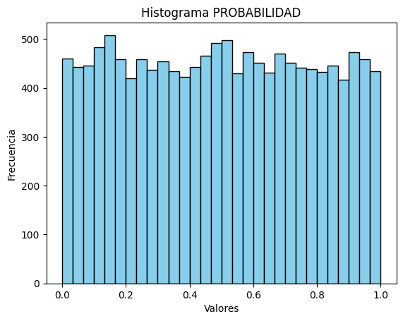

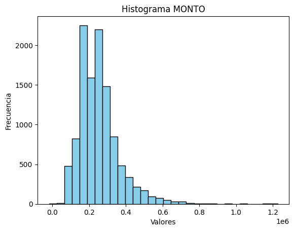

```python
plot_hist(df_cliente, ["PROBABILIDAD", "MONTO"])
```

```python
df_cliente[["MONTO", "PROBABILIDAD"]].describe()
```

|  | MONTO | PROBABILIDAD |
| --- | --- | --- |
| count | 1.120800e+04 | 13567.000000 |
| mean | 2.518180e+05 | 0.496974 |
| std | 1.100030e+05 | 0.288169 |
| min | -1.682550e+04 | 0.000100 |
| 25% | 1.768834e+05 | 0.247150 |
| 50% | 2.372826e+05 | 0.497700 |
| 75% | 2.933676e+05 | 0.744200 |
| max | 1.226104e+06 | 0.999700 |

**Nota tenemos clientes con montos negativos al ser solamente dos no se les dara importancia pero evidentemente se trata de un error debido a que no puede existir montos que paga el cliente en negativo**

```python
df_cliente[df_cliente["MONTO"] < 0]
```

|  | ID | ANTIGUEDAD | STATUS | MONTO | MEDIO_PAGO | PAQUETE | ID_OFERTA | MAPEO_PR | PROBABILIDAD |
| --- | --- | --- | --- | --- | --- | --- | --- | --- | --- |
| 5367 | LO0ZLO0ZLO4 | 60 Y MAS | ACTIVO | -16825.497 | 0 | DRAGONS | JSF89A | 2 | 0.1892 |
| 7491 | ZVLO04FA49 | 48 A 60 | ACTIVO | -5608.499 | BITCOIN | VIKING ARMOUR | JSF89A | 4 | 0.9728 |

**Nota tenemos clientes duplicados en la semantica**

```python
df_cliente["ID"].value_counts()[lambda x: x > 1]
```

```
ID
L800ZLO        5
LLOL9ZL04      5
L80LLO9LOV     5
LLLOZZVZ8      4
8LOLL4         4
              ..
LLZ04L8V       2
L8FA0LO0FA4    2
L8VFA0LL8      2
L9FA9ZLO84     2
LO0LO090LO0    2
Name: count, Length: 4041, dtype: int64
```

```python
df_cliente[df_cliente["ID"] == "L800ZLO"]
```

|  | ID | ANTIGUEDAD | STATUS | MONTO | MEDIO_PAGO | PAQUETE | ID_OFERTA | MAPEO_PR | PROBABILIDAD |
| --- | --- | --- | --- | --- | --- | --- | --- | --- | --- |
| 21 | L800ZLO | 07 A 11 | IMPAGO | 135898.245 | NO_IDENTIFICADO | DRAGONS | B92375 | 2 | 0.1055 |
| 9273 | L800ZLO | 07 A 11 | ACTIVO | 135898.245 | NO_IDENTIFICADO | DRAGONS | B92375 | 2 | 0.2199 |
| 9419 | L800ZLO | 12 A 23 | IMPAGO | 135898.245 | NO_IDENTIFICADO | DRAGONS | B92375 | 2 | 0.2894 |
| 10070 | L800ZLO | 12 A 23 | ACTIVO | 135898.245 | NO_IDENTIFICADO | DRAGONS | B92375 | 2 | 0.2587 |
| 13384 | L800ZLO | 07 A 11 | IMPAGO | 135898.245 | NO_IDENTIFICADO | DRAGONS | B92375 | 2 | 0.3188 |

```python
df_cliente["antiguedad_num"] = (
    df_cliente["ANTIGUEDAD"].str.extract(r"(\d+)").astype(float)
)

max_antiguedad = df_cliente.groupby("ID")["antiguedad_num"].transform("max")
df_cliente = df_cliente[df_cliente["antiguedad_num"] == max_antiguedad].drop(
    columns=["antiguedad_num"]
)
```

```python
df_cliente.reset_index(drop=True, inplace=True)
```

```python
df_cliente[df_cliente["ID"] == "L800ZLO"]
```

|  | ID | ANTIGUEDAD | STATUS | MONTO | MEDIO_PAGO | PAQUETE | ID_OFERTA | MAPEO_PR | PROBABILIDAD |
| --- | --- | --- | --- | --- | --- | --- | --- | --- | --- |
| 8407 | L800ZLO | 12 A 23 | IMPAGO | 135898.245 | NO_IDENTIFICADO | DRAGONS | B92375 | 2 | 0.2894 |
| 8876 | L800ZLO | 12 A 23 | ACTIVO | 135898.245 | NO_IDENTIFICADO | DRAGONS | B92375 | 2 | 0.2587 |

# Tabla final

```python
df = pd.merge(df_cliente, df_esf, how="left", on="ID")
```

```python
df = pd.merge(df, df_cat_oferta, how="left", on="ID_OFERTA")
```

```python
df = pd.merge(df, df_prem, how="left", on="ID")
```

```python
df = pd.merge(df, df_reino, how="left", on="ID")
```

```python
df = pd.merge(df, df_movcuenta, how="left", on="ID")
```

```python
df[
    [
        "GASTO",
        "PREMIUM",
        "COST_TOTAL_",
        "TOTAL_BAJA",
        "TOTAL_IMPAGO",
        "TOTAL_REINSTALACION",
    ]
] = (
    df[
        [
            "GASTO",
            "PREMIUM",
            "COST_TOTAL_",
            "TOTAL_BAJA",
            "TOTAL_IMPAGO",
            "TOTAL_REINSTALACION",
        ]
    ]
    .apply(pd.to_numeric, errors="coerce")
    .fillna(0, inplace=True)
)
```

[output not shown]

```python
df.info()
```

```
<class 'pandas.DataFrame'>
RangeIndex: 11428 entries, 0 to 11427
Data columns (total 17 columns):
 #   Column               Non-Null Count  Dtype
---  ------               --------------  -----
 0   ID                   11428 non-null  str
 1   ANTIGUEDAD           11428 non-null  str
 2   STATUS               11428 non-null  str
 3   MONTO                9333 non-null   float64
 4   MEDIO_PAGO           11428 non-null  str
 5   PAQUETE              11428 non-null  str
 6   ID_OFERTA            11428 non-null  str
 7   MAPEO_PR             11428 non-null  str
 8   PROBABILIDAD         11428 non-null  float64
 9   GASTO                11428 non-null  float64
 10  OFERTA               10966 non-null  str
 11  PREMIUM              11428 non-null  float64
 12  REINO                8532 non-null   str
 13  COST_TOTAL_          11428 non-null  float64
 14  TOTAL_BAJA           11428 non-null  float64
 15  TOTAL_IMPAGO         11428 non-null  float64
 16  TOTAL_REINSTALACION  11428 non-null  float64
dtypes: float64(8), str(9)
memory usage: 1.5 MB
```

```python
df["FLG_CLIENTE_TARGET"] = np.where(df["COST_TOTAL_"] > 0, 1, 0)
df["FLG_CLIENTE_BAJA"] = np.where(df["TOTAL_BAJA"] > 0, 1, 0)
df["FLG_CLIENTE_IMPAGO"] = np.where(df["TOTAL_IMPAGO"] > 0, 1, 0)
df["FLG_CLIENTE_REINSTALACION"] = np.where(df["TOTAL_REINSTALACION"] > 0, 1, 0)
```

```python
df.groupby("MAPEO_PR")[
    [
        "FLG_CLIENTE_TARGET",
        "FLG_CLIENTE_BAJA",
        "FLG_CLIENTE_IMPAGO",
        "FLG_CLIENTE_REINSTALACION",
    ]
].aggregate(["mean", "sum", "count"])
```

| MAPEO_PR | FLG_CLIENTE_TARGET mean | FLG_CLIENTE_TARGET sum | FLG_CLIENTE_TARGET count | FLG_CLIENTE_BAJA mean | FLG_CLIENTE_BAJA sum | FLG_CLIENTE_BAJA count | FLG_CLIENTE_IMPAGO mean | FLG_CLIENTE_IMPAGO sum | FLG_CLIENTE_IMPAGO count | FLG_CLIENTE_REINSTALACION mean | FLG_CLIENTE_REINSTALACION sum | FLG_CLIENTE_REINSTALACION count |
| --- | --- | --- | --- | --- | --- | --- | --- | --- | --- | --- | --- | --- |
| 0 | 0.604651 | 52 | 86 | 0.081395 | 7 | 86 | 0.523256 | 45 | 86 | 0.197674 | 17 | 86 |
| 1 | 0.481633 | 354 | 735 | 0.127891 | 94 | 735 | 0.370068 | 272 | 735 | 0.144218 | 106 | 735 |
| 2 | 0.411164 | 1208 | 2938 | 0.161334 | 474 | 2938 | 0.254935 | 749 | 2938 | 0.103472 | 304 | 2938 |
| 3 | 0.476460 | 253 | 531 | 0.154426 | 82 | 531 | 0.335217 | 178 | 531 | 0.116761 | 62 | 531 |
| 4 | 0.398496 | 1113 | 2793 | 0.176871 | 494 | 2793 | 0.227712 | 636 | 2793 | 0.076620 | 214 | 2793 |
| 5 | 0.514835 | 937 | 1820 | 0.019231 | 35 | 1820 | 0.495604 | 902 | 1820 | 0.210440 | 383 | 1820 |
| 6 | 0.375271 | 173 | 461 | 0.151844 | 70 | 461 | 0.223427 | 103 | 461 | 0.069414 | 32 | 461 |
| 7 | 0.577519 | 1192 | 2064 | 0.070736 | 146 | 2064 | 0.432171 | 892 | 2064 | 0.350291 | 723 | 2064 |

```python
df["FLG_CLIENTE_TARGET"].sum()
```

```
np.int64(5282)
```

```python
df.groupby("MAPEO_PR")[["COST_TOTAL_", "MONTO"]].aggregate(
    ["count", "median", "std", "max"]
)
```

| MAPEO_PR | COST_TOTAL_ count | COST_TOTAL_ median | COST_TOTAL_ std | COST_TOTAL_ max | MONTO count | MONTO median | MONTO std | MONTO max |
| --- | --- | --- | --- | --- | --- | --- | --- | --- |
| 0 | 86 | 35.9 | 43.631642 | 178.0 | 86 | 232968.420 | 72033.989010 | 485782.298 |
| 1 | 735 | 0.0 | 44.536463 | 268.8 | 732 | 189826.120 | 59269.210903 | 556967.093 |
| 2 | 2938 | 0.0 | 41.749691 | 285.2 | 2918 | 182923.352 | 75187.319573 | 1163116.408 |
| 3 | 531 | 0.0 | 46.198490 | 243.3 | 531 | 278267.835 | 90269.696913 | 689413.954 |
| 4 | 2793 | 0.0 | 38.191823 | 231.4 | 2793 | 297681.870 | 96113.427811 | 856374.655 |
| 5 | 1820 | 5.8 | 47.917733 | 250.2 | 1812 | 215711.500 | 70933.648467 | 726947.755 |
| 6 | 461 | 0.0 | 39.253233 | 177.5 | 461 | 444365.690 | 150140.019766 | 1226104.166 |
| 7 | 2064 | 21.6 | 50.343773 | 257.2 | 0 | NaN | NaN | NaN |

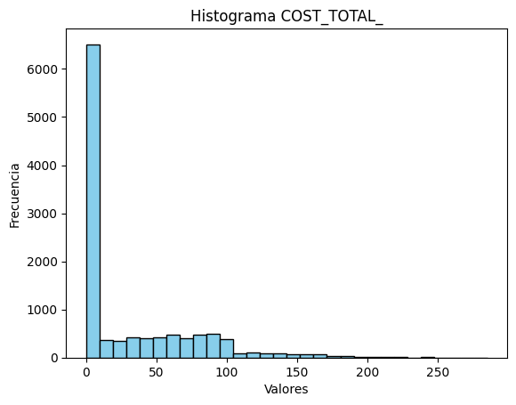

```python
plot_hist(df, ["COST_TOTAL_"])
```

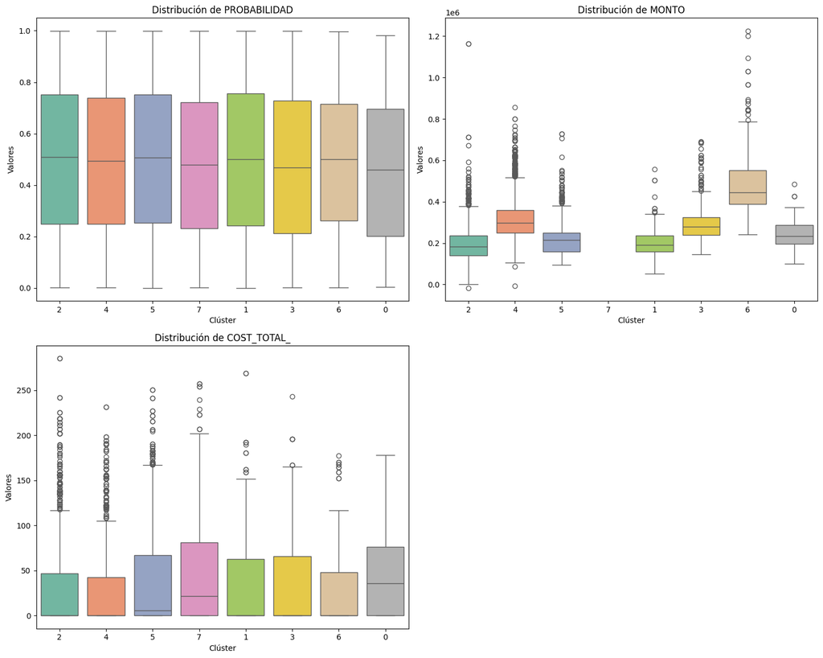

```python
plotbox(df, ["PROBABILIDAD", "MONTO", "COST_TOTAL_"], "MAPEO_PR")
```

```python
(
    pd.crosstab(
        df["MAPEO_PR"],
        df["ANTIGUEDAD"],
        normalize="index",  # Normaliza por filas (cada cluster suma 100%)
    )
    * 100
).round(2)
```

| ANTIGUEDAD MAPEO_PR | 00 A 06 | 07 A 11 | 12 A 23 | 24 A 47 | 48 A 60 | 60 Y MAS |
| --- | --- | --- | --- | --- | --- | --- |
| 0 | 0.00 | 2.33 | 54.65 | 36.05 | 4.65 | 2.33 |
| 1 | 0.00 | 10.34 | 42.86 | 28.44 | 6.67 | 11.70 |
| 2 | 0.00 | 6.40 | 26.86 | 22.23 | 7.76 | 36.76 |
| 3 | 0.00 | 0.56 | 15.44 | 43.31 | 14.12 | 26.55 |
| 4 | 0.00 | 0.90 | 10.85 | 31.19 | 10.85 | 46.22 |
| 5 | 55.16 | 44.84 | 0.00 | 0.00 | 0.00 | 0.00 |
| 6 | 0.00 | 0.00 | 0.43 | 20.82 | 12.80 | 65.94 |
| 7 | 30.23 | 10.42 | 17.25 | 18.70 | 7.12 | 16.28 |

```python
(
    pd.crosstab(
        df["MAPEO_PR"],
        df["PAQUETE"],
        normalize="index",  # Normaliza por filas (cada cluster suma 100%)
    )
    * 100
).round(2)
```

| PAQUETE MAPEO_PR | DRAGONS | NAVAL | NO_IDENTIFICADO | SOIL | SPURS | VIKING ARMOUR |
| --- | --- | --- | --- | --- | --- | --- |
| 0 | 6.98 | 1.16 | 0.00 | 18.60 | 31.40 | 41.86 |
| 1 | 20.14 | 4.76 | 0.27 | 28.71 | 19.59 | 26.53 |
| 2 | 36.62 | 5.28 | 0.31 | 18.31 | 12.01 | 27.47 |
| 3 | 1.32 | 7.91 | 0.75 | 1.69 | 35.03 | 53.30 |
| 4 | 3.04 | 8.31 | 0.82 | 1.32 | 18.69 | 67.81 |
| 5 | 5.33 | 0.11 | 0.38 | 17.86 | 28.24 | 48.08 |
| 6 | 0.43 | 3.25 | 1.52 | 0.87 | 10.41 | 83.51 |
| 7 | 8.67 | 2.03 | 19.96 | 10.17 | 24.42 | 34.74 |

```python
(
    pd.crosstab(
        df["MAPEO_PR"],
        df["MEDIO_PAGO"],
        normalize="index",  # Normaliza por filas (cada cluster suma 100%)
    )
    * 100
).round(2)
```

| MEDIO_PAGO MAPEO_PR | 0 | BITCOIN | ETHER | GOLD | NO_IDENTIFICADO | TYP2 | USD |
| --- | --- | --- | --- | --- | --- | --- | --- |
| 0 | 98.84 | 1.16 | 0.00 | 0.00 | 0.00 | 0.00 | 0.00 |
| 1 | 66.67 | 11.16 | 4.63 | 8.16 | 7.35 | 1.77 | 0.27 |
| 2 | 31.18 | 22.53 | 9.53 | 23.45 | 6.13 | 5.38 | 1.80 |
| 3 | 81.17 | 11.11 | 2.26 | 3.39 | 0.75 | 0.94 | 0.38 |
| 4 | 26.49 | 28.03 | 10.60 | 23.13 | 1.83 | 7.73 | 2.18 |
| 5 | 24.23 | 10.16 | 4.01 | 12.86 | 45.00 | 3.19 | 0.55 |
| 6 | 20.61 | 36.01 | 12.15 | 17.79 | 0.87 | 9.11 | 3.47 |
| 7 | 0.00 | 0.00 | 0.00 | 0.00 | 100.00 | 0.00 | 0.00 |

```python
df.groupby("MAPEO_PR")[["PREMIUM", "GASTO"]].aggregate(["mean", "sum", "count"])
```

| MAPEO_PR | PREMIUM mean | PREMIUM sum | PREMIUM count | GASTO mean | GASTO sum | GASTO count |
| --- | --- | --- | --- | --- | --- | --- |
| 0 | 0.011628 | 1.0 | 86 | 0.697674 | 60.0 | 86 |
| 1 | 0.021769 | 16.0 | 735 | 0.285714 | 210.0 | 735 |
| 2 | 0.021784 | 64.0 | 2938 | 0.158271 | 465.0 | 2938 |
| 3 | 0.094162 | 50.0 | 531 | 0.310734 | 165.0 | 531 |
| 4 | 0.112066 | 313.0 | 2793 | 0.171858 | 480.0 | 2793 |
| 5 | 0.011538 | 21.0 | 1820 | 0.114835 | 209.0 | 1820 |
| 6 | 0.242950 | 112.0 | 461 | 0.127983 | 59.0 | 461 |
| 7 | 0.000000 | 0.0 | 2064 | 0.003876 | 8.0 | 2064 |

```python
df[["GASTO", "PREMIUM", "COST_TOTAL_", "MONTO"]].describe()
```

|  | GASTO | PREMIUM | COST_TOTAL_ | MONTO |
| --- | --- | --- | --- | --- |
| count | 11428.000000 | 11428.000000 | 11428.000000 | 9.333000e+03 |
| mean | 0.144907 | 0.050490 | 30.873197 | 2.545043e+05 |
| std | 0.352023 | 0.218963 | 44.515073 | 1.129588e+05 |
| min | 0.000000 | 0.000000 | 0.000000 | -1.682550e+04 |
| 25% | 0.000000 | 0.000000 | 0.000000 | 1.768834e+05 |
| 50% | 0.000000 | 0.000000 | 0.000000 | 2.372826e+05 |
| 75% | 0.000000 | 0.000000 | 59.425000 | 2.981133e+05 |
| max | 1.000000 | 1.000000 | 285.200000 | 1.226104e+06 |

```python
df["ANTIGUEDAD"].value_counts() / len(df)
```

```
ANTIGUEDAD
60 Y MAS    0.283514
24 A 47     0.216661
12 A 23     0.165733
00 A 06     0.142457
07 A 11     0.115943
48 A 60     0.075691
Name: count, dtype: float64
```

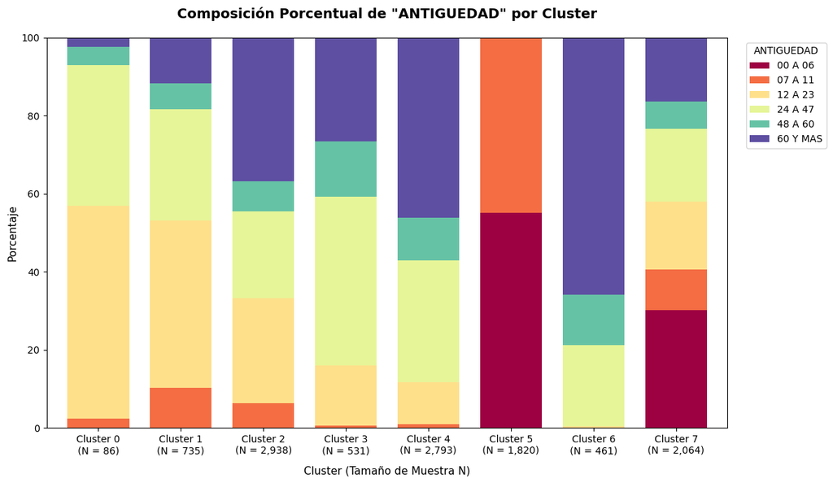

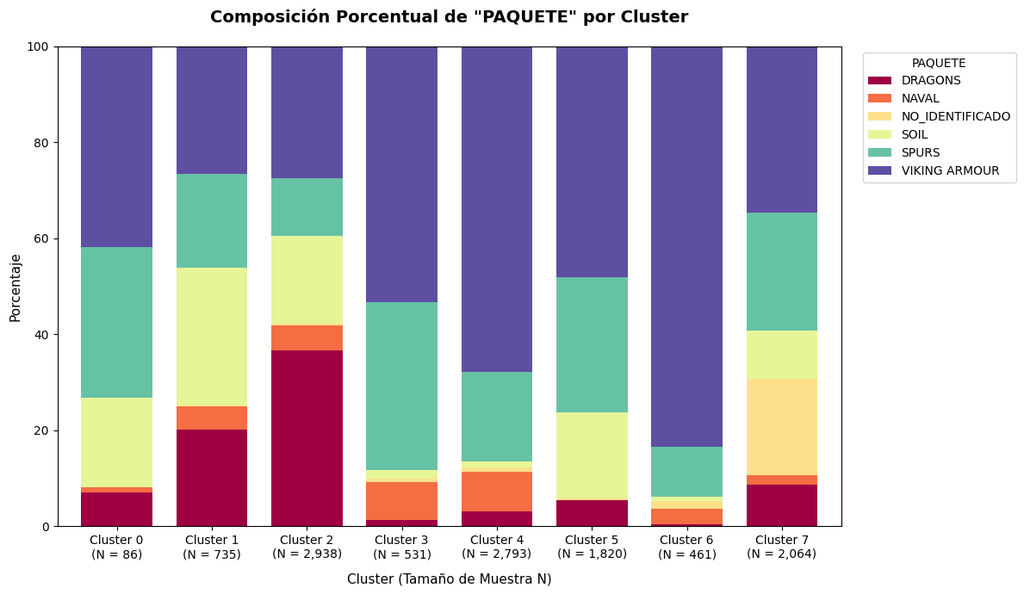

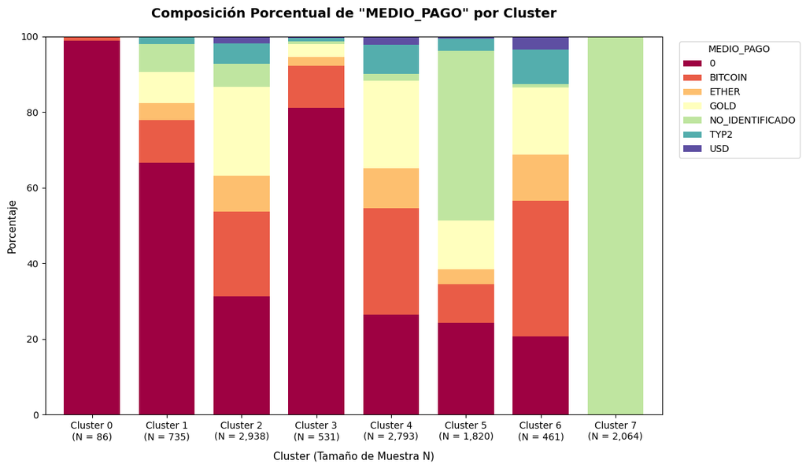

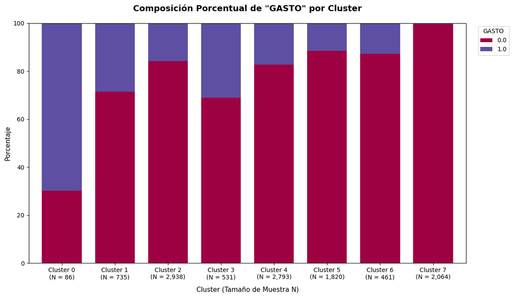

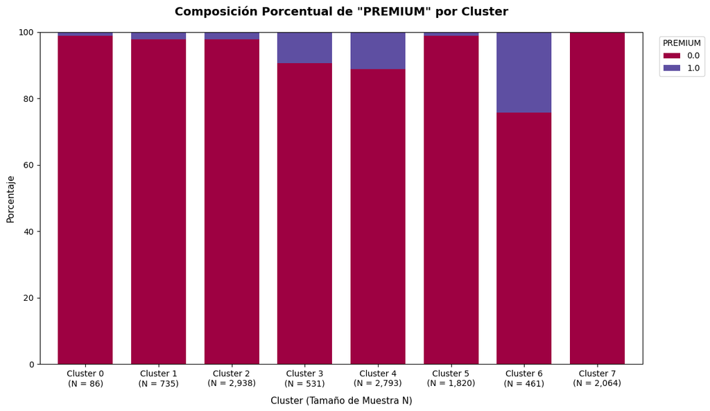

```python
plotbarra_acum(
    df,
    "MAPEO_PR",
    ["ANTIGUEDAD", "PAQUETE", "MEDIO_PAGO", "GASTO", "PREMIUM"],
)
```

```python
df.groupby("MAPEO_PR")[
    ["FLG_CLIENTE_BAJA", "FLG_CLIENTE_IMPAGO", "FLG_CLIENTE_REINSTALACION"]
].aggregate(["mean", "sum", "count"])
```

| MAPEO_PR | FLG_CLIENTE_BAJA mean | FLG_CLIENTE_BAJA sum | FLG_CLIENTE_BAJA count | FLG_CLIENTE_IMPAGO mean | FLG_CLIENTE_IMPAGO sum | FLG_CLIENTE_IMPAGO count | FLG_CLIENTE_REINSTALACION mean | FLG_CLIENTE_REINSTALACION sum | FLG_CLIENTE_REINSTALACION count |
| --- | --- | --- | --- | --- | --- | --- | --- | --- | --- |
| 0 | 0.081395 | 7 | 86 | 0.523256 | 45 | 86 | 0.197674 | 17 | 86 |
| 1 | 0.127891 | 94 | 735 | 0.370068 | 272 | 735 | 0.144218 | 106 | 735 |
| 2 | 0.161334 | 474 | 2938 | 0.254935 | 749 | 2938 | 0.103472 | 304 | 2938 |
| 3 | 0.154426 | 82 | 531 | 0.335217 | 178 | 531 | 0.116761 | 62 | 531 |
| 4 | 0.176871 | 494 | 2793 | 0.227712 | 636 | 2793 | 0.076620 | 214 | 2793 |
| 5 | 0.019231 | 35 | 1820 | 0.495604 | 902 | 1820 | 0.210440 | 383 | 1820 |
| 6 | 0.151844 | 70 | 461 | 0.223427 | 103 | 461 | 0.069414 | 32 | 461 |
| 7 | 0.070736 | 146 | 2064 | 0.432171 | 892 | 2064 | 0.350291 | 723 | 2064 |

```python
df[["FLG_CLIENTE_BAJA", "FLG_CLIENTE_IMPAGO", "FLG_CLIENTE_REINSTALACION"]].sum()
```

```
FLG_CLIENTE_BAJA             1402
FLG_CLIENTE_IMPAGO           3777
FLG_CLIENTE_REINSTALACION    1841
dtype: int64
```